# PSYC 259: Final Project

Samyukta Jayakumar

3/13/2022

## Brief Overview

The study focuses on understanding the effect of different properties of shapes on a Contour integration paradigm in patients with Schizophrenia and Neurotypical individuals. Contour integration is the process of identifying shapes made of disjoint but coherent and collinear elements from background elements that are similar in nature (noise). The study was administered using an iPad at three different sites:

- Nathan Kline Institute (NKI)
- Weill Cornell Medicine (CA)
- University of California, Riverside (UCR)

A total of 24 patients with Schizophrenia (SP) and 15 Neurotypical individuals (NT) were recruited for the study.

## Experimental Design

All participants underwent training for 40 sessions with SP performing one session per day and NT performing two sessions per day. All participants were trained on 15 different shapes, classified into 7 families of shapes, throughout their training period and the order of presentation of shapes was conserved between both the groups. Two parameters **Orientation Jitter (OJ)** and **Inducer Number (IN)** were manipulated during the training period using a combination of streaking and adaptive 3 down/1 up staircase method. This controlled the difficulty of training during each session.

The figure depicts some of the shapes presented during the study

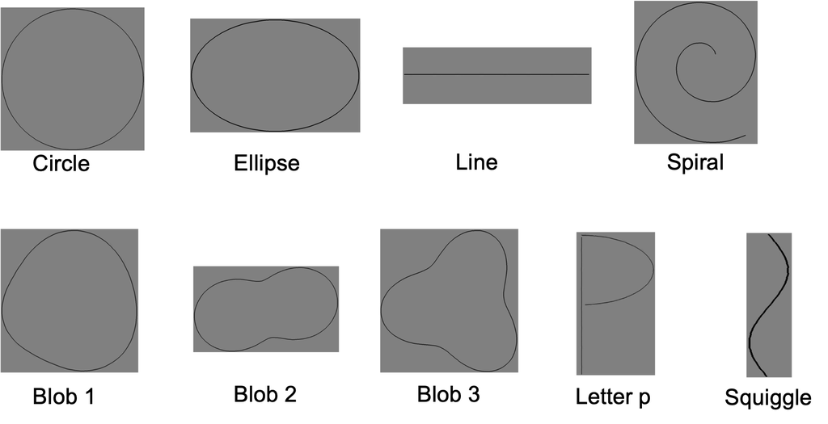

Fig 1: Subset of Contour Shapes presented during Training

## Analyses

For the purpose of the current project no training/learning effects were evaluated and only the performance of both groups on different shapes were assessed. In order to do this, thresholds were calculated as the average of all the reversal values over all blocks and all sessions for a particular shape that was presented to the participant. These thresholds were observed at both the orientation jitter and the inducer number level. Graphs were then plotted to see which group performed better and on which shape.

Several steps were involved in cleaning of data files before the data could be processed and visualized. MATALB 2020b software was used to perform data cleaning and analysis and the final plots were then visualized using the RStudio 2021.09.1 software.

**Note:** For purpose of efficiently sharing the data on Github, I’ve added only the relevant data files from `3 SP` and `3 NT` participants for *20 training sessions* and will be performing analyses only on the `Orientation Jitter` data using these files. The same procedure can then be followed for analysing the Inducer Number Data later.

### Step 1: Cleaning Log Files

An example of a typical participant log file looks like this: CA1005A_000_000_000_ContourChange*_19_02_07_15_29_36*.json This contains trailing details (italicized) about the time the data file was logged which makes it hard to read the individual files in the document. To circumvent that issue, I wrote a function on MATLAB that deletes this details and renames all the files within the folder. The function is as follows:

```
%% Renaming files
clear all
clc

files = dir ('*.json'); % Identifies all .json files within the directory
for i = 1:length(files)
    [~,names] = fileparts(files(i).name);
    expression = 'STS(\w+)\d'; %CA or NA or STS
    name2replace = names(1:end-18); % Removes the last 18 characters i.e. trailing details
    newname = regexprep(names,expression,name2replace);
    newjson = strcat(newname, '.json');
    movefile(files(i).name, newjson); % Replaces the file within the directory
end
```

### Step 2: Aggregating data for all participants across all sessions

The next step would be to create an aggregated data file that pools in the logs for all participants and each session. The code block below does this in matlab and stores 2 files

Previously, I used a hard coded format to do this as shown below:

```
% OLD CODE

part = [1005, 1018, 1028, 1005, 1018, 1002, 1012, 1016, 1002, 1016, 1017];
for p = 1:length(part)
    for i = 0:39
        for j = 0:1
            if  p < 4
                if i < 10
                    fname = (['CA' num2str(part(p)) 'A_00' num2str(i) '_000_00' num2str(j) '_ContourLog.json']);
                    val = jsondecode(fileread(fname));
                    Data_SP_40{p}{i+1,j+1} = val.data;
                else
                    fname = (['CA' num2str(part(p)) 'A_0' num2str(i) '_000_00' num2str(j) '_ContourLog.json']);
                    val = jsondecode(fileread(fname));
                    Data_SP_40{p}{i+1,j+1} = val.data;
                end
            else if p == 4
                    if i < 10
                        fname = (['Na' num2str(part(p)) 'A_00' num2str(i) '_000_00' num2str(j) '_ContourLog.json']);
                        val = jsondecode(fileread(fname));
                        Data_SP_40{p}{i+1,j+1} = val.data;
                    else
                        fname = (['Na' num2str(part(p)) 'A_0' num2str(i) '_000_00' num2str(j) '_ContourLog.json']);
                        val = jsondecode(fileread(fname));
                        Data_SP_40{p}{i+1,j+1} = val.data;
                    end
                else if p == 5
                        if i < 10
                            fname = (['NA' num2str(part(p)) 'A_00' num2str(i) '_000_00' num2str(j) '_ContourLog.json']);
                            val = jsondecode(fileread(fname));
                            Data_SP_40{p}{i+1,j+1} = val.data;
                        else
                            fname = (['NA' num2str(part(p)) 'A_0' num2str(i) '_000_00' num2str(j) '_ContourLog.json']);
                            val = jsondecode(fileread(fname));
                            Data_SP_40{p}{i+1,j+1} = val.data;
                        end
                    else if (p > 6 && p < 9)
                            if i < 10

                                fname = (['CA' num2str(part(p)) 'A_00' num2str(i) '_002_00' num2str(j) '_ContourLog.json']);
```

[output cut: 21 more lines]

```
                                    val = jsondecode(fileread(fname));
                                    Data_SP_40{p}{i+1,j+1} = val.data;
                                else
                                    fname = (['NA' num2str(part(p)) 'A_0' num2str(i) '_002_00' num2str(j) '_ContourLog.json']);
                                    val = jsondecode(fileread(fname));
                                    Data_SP_40{p}{i+1,j+1} = val.data;
                                end
                            end
                        end
                    end
                end
            end
        end
    end
end
```

**This has now been optimized as follows:**

1. Data log aggregate for all SP named as `SP_Data.mat`
2. Data log aggregate for the summary file for each session and participant named as `SP_summary.mat`

Each row corresponds to a participant and each column corresponds to a session, so we have `3x20` data file of cell format

I used a code that loops through all participant files within the directory and separate them based on their session without hard coding the participant detail which was a major issue previously. I could also save them without checking if the data was correctly isolated using this method.

```
%% For aggregating individual data log file for each participant

files = dir('*.json'); % Identifies all .json files from the directory
count = 1;
part_cmp = 'CA1005A'; % Reference participant # to begin the loop
for i = 1:length(files)
    [~,names] = fileparts(files(i).name);
    cmp_name = names(end-9:end);
    log_name = 'ContourLog'; % Isolates the log file name
    part_name = names(1:7);  % Isolates the participant name
    ses_name = names(10:11); % Isolates the session #
    run_name = names(18:19); % Isolates the run #
    ses = str2double(regexp(ses_name,'\d*','match'));
    run = str2double(regexp(run_name,'\d*','match'));
    if sum(part_name ~= part_cmp) > 0 % Comparing strings
        count = count + 1;
        part_cmp = part_name;
        if cmp_name == log_name
            fname = (files(i).name);
            val = jsondecode(fileread(fname));
            SP{count,ses+1}{1,run+1} = val.data; % Enters participants as rows and sessions as columns in a cell format
        end
    else
        if cmp_name == log_name
            fname = (files(i).name);
            val = jsondecode(fileread(fname));
            SP{count,ses+1}{1,run+1} = val.data;
        end
    end
end
save('SP_data', 'SP')
```

A similar method was used to create two aggregate matrices for NT group as well. They were named `NT_data.mat` and `NT_summary.mat`

### Step 3: Isolating data for each Contour Shape for all participants across all sessions

The first step towards analysing the data would be to isolate participant and session wise information for all families of Contour shapes i.e., `Circle`, `Lines`, `Ellipses`, `Spiral`, `Blobs`, `Squiggles` and `Letters`.

To do this we must first use a `for` loop that runs through every participant and every session and isolates the shape wise information. This is done using the following piece of code from MATLAB

```
for i = 1:size(SP,1) % For each participant
    for j = 1:size(SP,2) % For each session
        % Setting counters for each Family
        count1 = 0;
        count2 = 0;
        count3 = 0;
        count4 = 0;
        count5 = 0;
        count6 = 0;
        count7 = 0;
        if ~isempty(SP_summary{i,j})
            for k = 1:length(SP_summary{i,j})
                if contains(SP_summary{i,j}{k,1}.game_type, Contour)
                    if contains(SP_summary{i,j}{k,1}.contour_parameter, OrientationJitter)
                        run = SP_summary{i,j}{k,1}.run + 1;
                        if strcmp(SP_summary{i,j}{k,1}.contour_class, Circle_General) % Comparing strings within the summary file to isolate runs when Circle shape was presented
                            count1 = count1 + 1;
                            Circle{i,j}{count1,1} = SP{i,j}{1,run};
                        elseif strcmp(SP_summary{i,j}{k,1}.contour_class, Line_V) || strcmp(SP_summary{i,j}{k,1}.contour_class, Line_H)
                            count2 = count2 + 1;
                            Lines{i,j}{count2,1} = SP{i,j}{1,run};
                        elseif strcmp(SP_summary{i,j}{k,1}.contour_class, Ellipse_V) || strcmp(SP_summary{i,j}{k,1}.contour_class, Ellipse_H) || strcmp(SP_summary{i,j}{k,1}.contour_class, Ellipse_R)
                            count3 = count3 + 1;
                            Ellipses{i,j}{count3,1} = SP{i,j}{1,run};
                        elseif strcmp(SP_summary{i,j}{k,1}.contour_class, Spiral_General)
                            count4 = count4 + 1;
                            Spiral{i,j}{count4,1} = SP{i,j}{1,run};
                        elseif strcmp(SP_summary{i,j}{k,1}.contour_class, Blob_1) || strcmp(SP_summary{i,j}{k,1}.contour_class, Blob_2) || strcmp(SP_summary{i,j}{k,1}.contour_class, Blob_3)
                            count5 = count5 + 1;
                            Blobs{i,j}{count5,1} = SP{i,j}{1,run};
                        elseif strcmp(SP_summary{i,j}{k,1}.contour_class, Squiggle_V) || strcmp(SP_summary{i,j}{k,1}.contour_class, Squiggle_H)
                            count6 = count6 + 1;
                            Squiggles{i,j}{count6,1} = SP{i,j}{1,run};
                        else
                            if strcmp(SP_summary{i,j}{k,1}.contour_class, Letter_B) || strcmp(SP_summary{i,j}{k,1}.contour_class, Letter_D) || strcmp(SP_summary{i,j}{k,1}.contour_class, Letter_P)
                                count7 = count7 + 1;
                                Letters{i,j}{count7,1} = SP{i,j}{1,run};
                            end
                        end
                    end
                end
            end
        end
    end
end
```

The above code is for isolating the `Orientation Jitter` parameter. The same code is used to isolate the second parameter - `Inducer Number` by replacing the following line of code in the previous code block `if contains(SP_summary{i,j}{k,1}.contour_parameter, OrientationJitter)` with `if contains(SP_summary{i,j}{k,1}.contour_parameter, InducerNumber)`

### Step 4: Identifying Orientation Jitter Thresholds

As stated previously, two variables of interest needs to be isolated for each participant across all sessions for each Contour shape. The first parameter is the `Orientation Jitter threshold` which is the maximum tolerable deviation in the orientation of the individual elements that make up the shape. Following is the code used to isolate the `OJ Threshold` for all SP participants and all sessions for each contour shape. This is written as a `customized function` in MATLAB for optimizing the code to function with inputs from different shapes and groups.

```
function [Threshold] = isolate_threshold(input_mat)

for ii = 1:size(input_mat,1)
    for jj = 1:size(input_mat,2)
        if isempty(input_mat{ii,jj}) == 1
            avg_thresh_ori = NaN;
            Thresh_ori = NaN;
        else
            for kk = 1:length(input_mat{ii,jj})
                count_ori = [];
                for mm = 4:length(input_mat{ii,jj}{kk,1})
                    count_ori = [count_ori ; input_mat{ii,jj}{kk,1}(mm,1).orientationJitter];
                end
                thresh_ori = [];
                flag_ori = 0;
                for ll = 1:length(count_ori) - 1
                    c = 0;
                    if count_ori(ll+1) < count_ori(ll) && flag_ori == 0
                        thresh_ori = [thresh_ori ; count_ori(ll)];
                        flag_ori = 1;
                    end
                    if count_ori(ll+1) > count_ori(ll) && flag_ori == 1
                        thresh_ori = [thresh_ori ; count_ori(ll)];
                        flag_ori = 0;
                    end
                end
                avg_thresh_ori = mean(thresh_ori,'omitnan');
                Thresh_ori(kk,1) = avg_thresh_ori;
                clear count_ori
            end
        end
        Threshold(ii,jj) = mean(Thresh_ori,'omitnan');
        clear avg_thresh_ori; clear Thresh_ori;
    end
end
```

This was repeated for all Contour shapes. Once the thresholds were isolated, I calculated the average threshold for each shape by taking the average of all participants over all sessions and estimated the within subject standard error as follows for each shape. Following is an example for the `Circle` contour shape.

```
Circle_OJ_pmeans = nanmean(Circle_OJ_thresh,2); %participant means over 40 sessions
Circle_OJ_thresh_final = nanmean(Circle_OJ_pmeans);
% Within subject SE
Circle_win_se_val = Circle_OJ_pmeans - Circle_OJ_thresh_final;
Circle_win_sd = nanstd(Circle_win_se_val);
Circle_OJ_win_se = Circle_win_sd./(size(Circle_OJ_pmeans(~isnan(Circle_OJ_pmeans)),1) ^ (1/2));
```

### Step 5: Saving the aggregate data as .csv files for visualization

The thresholds calculated in the above steps were then stored in .csv files and the data was visualized using RStudio. The MATLAB code used to save the data as a .csv file is as follows

```
Shapes = ["Circle";"Lines";"Ellipses";"Spiral";"Blobs";"Squiggles";"Letters";...
    "Circle";"Lines";"Ellipses";"Spiral";"Blobs";"Squiggles";"Letters"];

Mean = [Circle_SP(4,1);Lines_SP(4,1);Ellipses_SP(4,1);Spiral_SP(4,1)...
    ;Blobs_SP(4,1);Squiggles_SP(4,1);Letters_SP(4,1);...
    Circle_NT(4,1);Lines_NT(4,1);Ellipses_NT(4,1);Spiral_NT(4,1)...
    ;Blobs_NT(4,1);Squiggles_NT(4,1);Letters_NT(4,1)];

SE = [Circle_SP(5,1);Lines_SP(5,1);Ellipses_SP(5,1);Spiral_SP(5,1)...
    ;Blobs_SP(5,1);Squiggles_SP(5,1);Letters_SP(5,1);...
    Circle_NT(5,1);Lines_NT(5,1);Ellipses_NT(5,1);Spiral_NT(5,1)...
    ;Blobs_NT(5,1);Squiggles_NT(5,1);Letters_NT(5,1)];

Group = ["SP";"SP";"SP";"SP";"SP";"SP";"SP";"NT";"NT";"NT";"NT";"NT";"NT";"NT"];
OJ = table(Group,Shapes,Mean,SE);
writetable(OJ,'OJ.csv');
```

### Step 6: Data Visualization

Previously, I was visualizing the data in MATLAB that used long lines of code to generate a simple bar graph as follows:

```
x = 1:7
y = [SP_count_thresh, NT_count_thresh];
err = [SP_count_win_se, NT_count_win_se];
b = bar(y,'grouped');
hold on
% Find the number of groups and the number of bars in each group
[ngroups, nbars] = size(y);
% Calculate the width for each bar group
groupwidth = min(0.8, nbars/(nbars + 1.5));
% Set the position of each error bar in the centre of the main bar
% Based on barweb.m by Bolu Ajiboye from MATLAB File Exchange
for i = 1:nbars
    % Calculate center of each bar
    x = (1:ngroups) - groupwidth/2 + (2*i-1) * groupwidth / (2*nbars);
    errorbar(x, y(:,i), err(:,i), 'k', 'linestyle', 'none');
end
hold off

set(gca,'xtick',x_id,'xticklabel',names,'fontsize',19)
xtickangle(45)
xlim([0 7])
xlabel('Contour Shapes','fontsize',26);
ylabel('Inducer Number Thresholds','fontsize',26);
grid on;
title('Inducer Number Thresholds for SP and NT','fontsize',28)
legend('SP','NT', 'location','northeast')
```

R studio optimizes plotting and visualization of data to generate concise graphs that are visually pleasant and very time efficient.

Here, I plot Bar graphs to visualize the family-wise threshold data for both SP and NT groups separately and also compared with each other. The following R code generates a graph denoting the **Family - wise Average OJ thresholds for SP and NT groups**

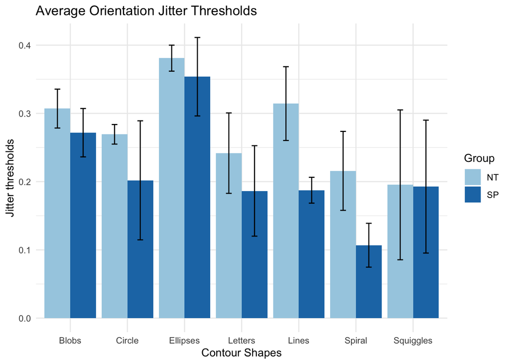

```r
OJ <- read_csv('OJ.csv')

# Plotting graph for all Contour Shapes

p <- ggplot(OJ, aes(x=Shapes, y=Mean, fill=Group)) +
   geom_bar(stat="identity", position=position_dodge()) +
  geom_errorbar(aes(ymin=Mean-SE, ymax=Mean+SE), width=.2,
                 position=position_dodge(.9))
p + labs(title="Average Orientation Jitter Thresholds",
         x="Contour Shapes", y = "Jitter thresholds") + scale_fill_brewer(palette="Paired") + theme_minimal()
```

Similar codes were used to analyse the data for the **Inducer Number** parameter as well. For ease, I’ve just included the final .csv file generated and plot the graphs showing **Family - wise Average IN thresholds for SP and NT groups** below

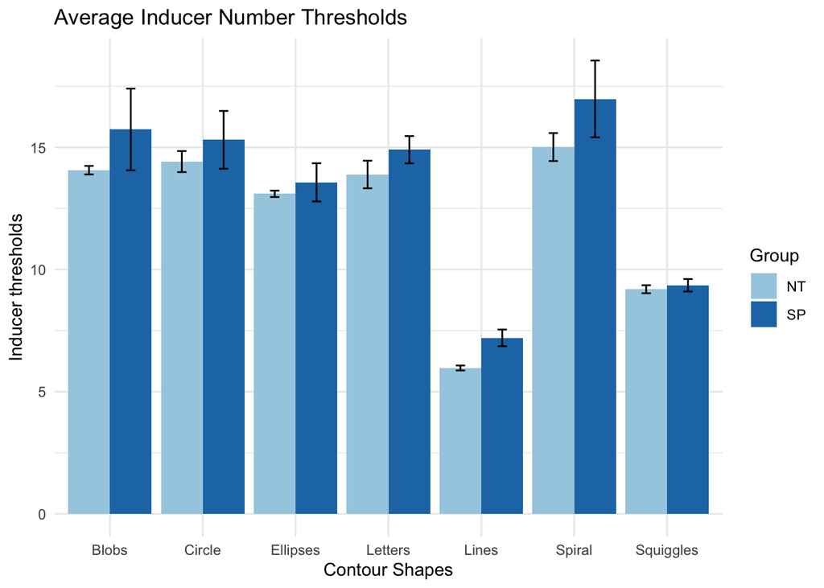

```r
IN <- read_csv('IN.csv')

# Plotting graph for all Contour Shapes

p <- ggplot(IN, aes(x=Shapes, y=Mean, fill=Group)) +
   geom_bar(stat="identity", position=position_dodge()) +
  geom_errorbar(aes(ymin=Mean-SE, ymax=Mean+SE), width=.2,
                 position=position_dodge(.9))
p + labs(title="Average Inducer Number Thresholds",
         x="Contour Shapes", y = "Inducer thresholds") + scale_fill_brewer(palette="Paired") + theme_minimal()
```